# Mayo Clinic PBC Trial Survival Analysis

Jiahe Tian

2026-09-16

## Research Question

Among randomized participants in the Mayo Clinic PBC trial, was there evidence of a difference in survival between the D-penicillamine and placebo treatment groups?

## Data Source

This analysis uses data from the Mayo Clinic randomized trial in primary biliary cirrhosis (PBC), available through the `survival` R package and the Rdatasets repository.

The dataset includes baseline clinical and laboratory measurements, treatment assignment, follow-up time, and survival status. The randomized portion of the study compared D-penicillamine with placebo.

For this analysis, we restrict the study population to randomized participants with known treatment assignments.

## Setup

```r
# Install the required package if it is not already available
if (!requireNamespace("survival", quietly = TRUE)) {
  install.packages(
    "survival",
    repos = "https://cloud.r-project.org"
  )
}

library(survival)
```

## Load Data

```r
url <- "https://vincentarelbundock.github.io/Rdatasets/csv/survival/pbc.csv"

pbc <- read.csv(url)

head(pbc)
```

```
##   rownames id time status trt      age sex ascites hepato spiders edema bili
## 1        1  1  400      2   1 58.76523   f       1      1       1   1.0 14.5
## 2        2  2 4500      0   1 56.44627   f       0      1       1   0.0  1.1
## 3        3  3 1012      2   1 70.07255   m       0      0       0   0.5  1.4
## 4        4  4 1925      2   1 54.74059   f       0      1       1   0.5  1.8
## 5        5  5 1504      1   2 38.10541   f       0      1       1   0.0  3.4
## 6        6  6 2503      2   2 66.25873   f       0      1       0   0.0  0.8
##   chol albumin copper alk.phos    ast trig platelet protime stage
## 1  261    2.60    156   1718.0 137.95  172      190    12.2     4
## 2  302    4.14     54   7394.8 113.52   88      221    10.6     3
## 3  176    3.48    210    516.0  96.10   55      151    12.0     4
## 4  244    2.54     64   6121.8  60.63   92      183    10.3     4
## 5  279    3.53    143    671.0 113.15   72      136    10.9     3
## 6  248    3.98     50    944.0  93.00   63       NA    11.0     3
```

## Data Inspection

Before preparing the analysis dataset, we inspect the dimensions, variables, treatment assignments, and outcome information in the original PBC dataset.

```r
dim(pbc)
```

```
## [1] 418  21
```

```r
names(pbc)
```

```
##  [1] "rownames" "id"       "time"     "status"   "trt"      "age"
##  [7] "sex"      "ascites"  "hepato"   "spiders"  "edema"    "bili"
## [13] "chol"     "albumin"  "copper"   "alk.phos" "ast"      "trig"
## [19] "platelet" "protime"  "stage"
```

```r
table(pbc$trt, useNA = "ifany")
```

```
##
##    1    2 <NA>
##  158  154  106
```

```r
table(pbc$status)
```

```
##
##   0   1   2
## 232  25 161
```

## Outcome Definition

The outcome of interest is time to death. Follow-up time (`time`) is measured in days.

Death (`status = 2`) is treated as the event of interest. Participants who were alive at the end of follow-up (`status = 0`) are censored. Participants who underwent liver transplantation (`status = 1`) are censored at the time of transplantation.

Therefore, a binary event indicator is created as:

- `event = 1`: death
- `event = 0`: censored or liver transplantation

## Data Preparation

The analysis is restricted to participants with a randomized treatment assignment. Treatment is relabeled for readability, and a binary death indicator is created for the survival analysis.

```r
pbc_randomized <- pbc[!is.na(pbc$trt), ]

pbc_randomized$treatment <- ifelse(
  pbc_randomized$trt == 1,
  "D-penicillamine",
  "Placebo"
)

pbc_randomized$event <- ifelse(
  pbc_randomized$status == 2,
  1,
  0
)
```

### Data Checks

```r
dim(pbc_randomized)
```

```
## [1] 312  23
```

```r
table(pbc_randomized$treatment)
```

```
##
## D-penicillamine         Placebo
##             158             154
```

```r
# check derived outcome variable
table(
  Status = pbc_randomized$status,
  Event = pbc_randomized$event
)
```

```
##       Event
## Status   0   1
##      0 168   0
##      1  19   0
##      2   0 125
```

```r
# check if there is any missing value
colSums(
  is.na(
    pbc_randomized[, c("time", "event", "treatment")]
  )
)
```

```
##      time     event treatment
##         0         0         0
```

## Descriptive Summary

We first summarize the number of randomized participants and deaths by treatment group before comparing the survival distributions.

```r
table(pbc_randomized$treatment)
```

```
##
## D-penicillamine         Placebo
##             158             154
```

```r
aggregate(
  event ~ treatment,
  data = pbc_randomized,
  FUN = sum
)
```

```
##         treatment event
## 1 D-penicillamine    65
## 2         Placebo    60
```

## Kaplan–Meier Survival Analysis

Kaplan–Meier survival curves were estimated separately for the D-penicillamine and placebo groups. Death was treated as the event of interest, while participants who underwent liver transplantation or remained alive at the end of follow-up were censored.

```r
surv_object <- Surv(
  time = pbc_randomized$time,
  event = pbc_randomized$event
)

km_fit <- survfit(
  surv_object ~ treatment,
  data = pbc_randomized
)

km_fit
```

```
## Call: survfit(formula = surv_object ~ treatment, data = pbc_randomized)
##
##                             n events median 0.95LCL 0.95UCL
## treatment=D-penicillamine 158     65   3282    2583      NA
## treatment=Placebo         154     60   3428    3090      NA
```

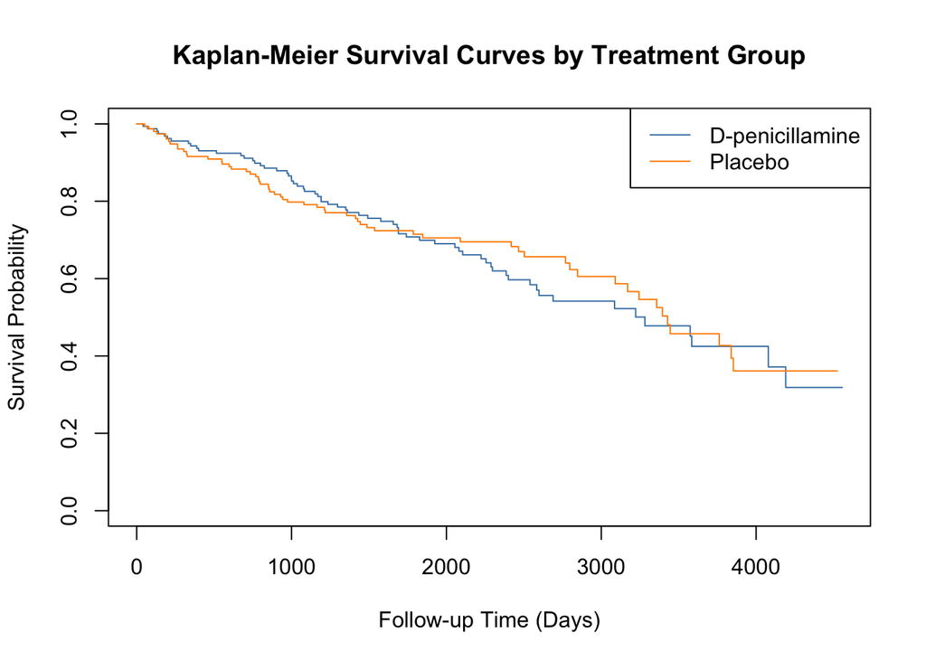

```r
plot(
  km_fit,
  xlab = "Follow-up Time (Days)",
  ylab = "Survival Probability",
  main = "Kaplan-Meier Survival Curves by Treatment Group",
  conf.int = FALSE,
  mark.time = FALSE,
  col = c("steelblue", "darkorange")
)

legend(
  "topright",
  legend = c("D-penicillamine", "Placebo"),
  lty = 1,
  col = c("steelblue", "darkorange")
)
```

*AI usage: I used ChatGPT for guidance on customizing the R Kaplan–Meier plot to make its appearance comparable to the Python version, particularly for matching the plot colors.*

## Log-Rank Test

A log-rank test was used to formally compare the survival distributions between the D-penicillamine and placebo groups.

```r
logrank_result <- survdiff(
  surv_object ~ treatment,
  data = pbc_randomized
)

logrank_result
```

```
## Call:
## survdiff(formula = surv_object ~ treatment, data = pbc_randomized)
##
##                             N Observed Expected (O-E)^2/E (O-E)^2/V
## treatment=D-penicillamine 158       65     63.2    0.0502     0.102
## treatment=Placebo         154       60     61.8    0.0513     0.102
##
##  Chisq= 0.1  on 1 degrees of freedom, p= 0.7
```

```r
p_value <- 1 - pchisq(
  logrank_result$chisq,
  df = 1
)

round(p_value, 3)
```

```
## [1] 0.75
```

## Interpretation

The Kaplan–Meier curves for the D-penicillamine and placebo groups were generally similar over the follow-up period. The curves crossed at several points, and neither treatment group showed a consistently higher survival probability than the other.

Using a significance level of $\alpha$ = 0.05, the log-rank test did not show a statistically significant difference in the survival distributions between the two treatment groups (p = 0.75). Since the p-value was greater than 0.05, we failed to reject the null hypothesis of equal survival distributions.

Overall, this unadjusted analysis did not provide evidence of a difference in survival between participants assigned to D-penicillamine and those assigned to placebo.

## Python vs. R Comparison

For this analysis, R was faster for me to write and was also the implementation I felt more confident using. I have more experience using R for statistical analyses, including survival analysis, so the workflow using `Surv()`, `survfit()`, and `survdiff()` was relatively direct and familiar. In contrast, the Python implementation required me to set up an appropriate environment and install the `lifelines` package before performing the survival analysis. I also needed to manage the Python environment carefully so that the analysis could be reproduced.

I have slightly more confidence in the R implementation because of my greater familiarity with R and the well-established `survival` package. However, the Python and R implementations produced essentially the same Kaplan–Meier curves and log-rank test result (p = 0.75). The agreement between the two independent implementations increases my confidence in the overall analysis and suggests that the results were not dependent on the choice of software.